# (IN PROGRESS!!)25 anos de Chumbo em alimentos:

Estudo da distribuição mundial da contaminação de alimentos por Chumbo usando a base de dados GEMSFOODS(OMS) no período de 1995-2020

Fabiano Silva (drhtcl@gmail.com)

# 1. Introdução

O Chumbo(Pb) é o segundo metal mais tóxico depois do arsênio (As), compreende 0,002% da crosta terrestre.

O chumbo, como outros metais pesados, não se biodegrada nem desaparece do meio ambiente com o tempo. Embora os níveis de chumbo no suprimento de alimentos tenham diminuído drasticamente entre as décadas de 1970 e 1990, baixos níveis de chumbo continuam a ser detectados em alguns alimentos devido à presença contínua no meio ambiente. O chumbo do solo pode ser absorvido por plantas cultivadas para obtenção de frutas ou vegetais ou plantas usadas como ingredientes em alimentos ou ração animal.

O chumbo é venenoso para o ser humano e pode afetar pessoas de qualquer idade ou estado de saúde. O chumbo é especialmente prejudicial para as populações vulneráveis, incluindo bebês, crianças pequenas, mulheres grávidas e seus fetos e outras pessoas com condições crônicas de saúde. Altos níveis de exposição ao chumbo podem prejudicar seriamente a saúde e o desenvolvimento das crianças, especificamente o cérebro e o sistema nervoso. Os efeitos neurológicos de altos níveis de exposição ao chumbo durante a primeira infância incluem dificuldades de aprendizagem, dificuldades de comportamento e QI reduzido. Como o chumbo pode se acumular no corpo, mesmo a exposição crônica de baixo nível pode ser perigosa ao longo do tempo.

Estima-se que a exposição ao chumbo foi responsável, em 2004, por 143 mil mortes e 0,6% da carga global de doenças, levando em consideração retardo mental leve e desfechos cardiovasculares

# 1.1 Objetivo

O objetivo deste trabalho é:

1- investigar o conteúdo de Chumbo nos alimentos utilizando a linguagem R como meio de filtragem, análise e modelagem das distribuições conforme as variedades de alimentos consumidos, países, condições analíticas e datas.

2- Descobrir onde e quais alimentos apresentam maior contaminação e criar possíveis hipóteses de causa.

# 2. Dados iniciais e ingestão da base da dados:

As informações foram retirados da base de dados “GEMSFOODS” da Organização Mundial da Saúde (OMS) presente no endereço:

https://extranet.who.int/gemsfood/

Todos os cálculos e gráficos foram feitos em **Rstudio versão 1.3.959** e **R base 3.6.3** e utilizando as seguintes bibliotecas:

```r
library(readr)
library(ggplot2)
library(tidyverse)
library(knitr)
library(RColorBrewer)
library(ggalluvial)
library(treemapify)
```

Os códigos empregados para executar esse trabalha serão deixados a mostra. Todo o processamento é baseado em padrões mais modernos em reprodutibilidade [red] em pesquisa onde, dados individuais não são manipulados e todo o processo (do reconhecimento do bancos de dados ao relatório final) é feito de forma automatizada e pode ser auditado pelas linhas de código empregado.

Começamos consolidando a base de dados, os arquivos foram baixados em grupos para facilitar o download:

```r
GEMS2000 <- read.csv("/mnt/DADOS/Data Science/GEMFoods/Gemsfood(1980-2000).csv", dec=",")
GEMS2010 <- read.csv("/mnt/DADOS/Data Science/GEMFoods/Gemsfood(2000-2010).csv", dec=",")
GEMS2014 <- read.csv("/mnt/DADOS/Data Science/GEMFoods/Gemsfood(2010-2014).csv", dec=",")
GEMS2016 <- read.csv("/mnt/DADOS/Data Science/GEMFoods/Gemsfood(2014-2016).csv", dec=",")
GEMS2018 <- read.csv("/mnt/DADOS/Data Science/GEMFoods/Gemsfood(2016-2018).csv", dec=",")
GEMS2020 <- read.csv("/mnt/DADOS/Data Science/GEMFoods/Gemsfood(2018-2020).csv", dec=",")

GEMS <- rbind(GEMS2000,GEMS2010,GEMS2014,GEMS2016,GEMS2018,GEMS2020)
```

# 3. Principais variáveis:

Verificando os tipos de informações disponíveis:

```r
names(GEMS)
##  [1] "RecordType"              "RegionName"
##  [3] "CountryName"             "ContaminantName"
##  [5] "FoodCategory"            "FoodName"
##  [7] "FoodCode"                "LocalFoodName"
##  [9] "FoodStateName"           "ResultValue"
## [11] "ResultText"              "UnitName"
## [13] "LOD"                     "LOQ"
## [15] "LODMin"                  "LODMax"
## [17] "LOQMin"                  "LOQMax"
## [19] "Mean"                    "MeanLower"
## [21] "MeanUpper"               "Median"
## [23] "NinetiethPercentile"     "StandardDeviation"
## [25] "SamplingPeriodStart"     "SamplingPeriodStartText"
## [27] "SamplingPeriodEnd"       "SamplingPeriodEndText"
## [29] "RepresentativenessName"  "LabCount"
## [31] "LabNumber"               "FoodOriginName"
## [33] "AnalyticalQAName"        "SampleCount"
## [35] "SamplesBelowLOQ"         "RangeMin"
## [37] "RangeMax"                "ResultBasisName"
## [39] "PortionTypeName"         "SerialNumber"
## [41] "RowNum"
```

Os dados utilizados serão: “CountryName” ou seja o pais de origem dos dados analíticos, “FoodCategory” O tipo de alimento, ou seja, a matriz analítica como “Vegetais” ou “Ração Animal”, “FoodOriginName”, que descreve a origem como Domestica ou importada, “LOQ” o limite de quantificação, “ResultValue”, o valor obtido na análise quando quantificado, “AnalyticalQAName”, que descreve as condições da análise, como feita em laboratório acreditado ou uso de controle de qualidade interno somente e “FoodName” que é a descrição exata do alimento como “Batata” ou “Arroz”,

Antes, dever ser feita a avaliação das unidades do teor de Chumbo:

```r
summary(GEMS$UnitName)
##  mg/kg  ug/kg
## 123819 240956
```

Quando quantificado, o resultado foi reportado em duas unidades diferentes, mg/kg e ug/kg.

Todas as unidades serão alteradas para mg/kg e os valores ajustados para a mesma unidade, sendo que 1ug/kg é equivalente a 0,001mg/kg:

```r
for(i in 1:nrow(GEMS)){
  if(GEMS[i,12]=="ug/kg"){
     GEMS[i,14] <- GEMS[i,14]/1000
     GEMS[i,10] <- GEMS[i,10]/1000
     GEMS[i,12] <- "mg/kg"
  } else {
  NULL
  }
}
```

Confirmando a alteração:

```
##  mg/kg  ug/kg
## 364775      0
```

O Limite de quantificação também foi alterado(Coluna 14 )

# 4. Análise exploratória e busca das maiores contaminações:

## 4.1 Distribuição da origem dos dados

Vamos visualizar de uma maneira prática quais paises contribuiram mais para o banco de dados da OMS usando a variável CountryName e quantas vezes um determinado pais aparece:

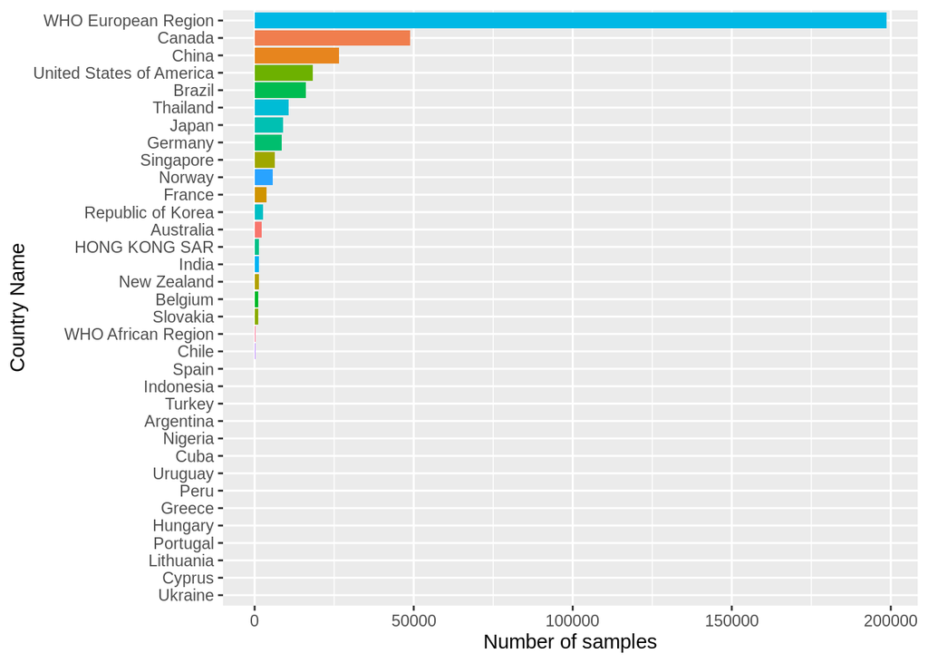

```r
ggplot(GEMS, aes(x=reorder(CountryName,CountryName,function(x)+length(x)), fill=CountryName, ))+geom_bar(show.legend= FALSE)+ coord_flip()+xlab("Country Name")+ylab("Number of samples")
```

Figura 1. Número de amostras por contribuinte do banco de dados no período de 1995 a 2020.

“WHO European Region”, “China”, “Canada”, “United States of America”, “Brazil” e “Thailand” são os principais contribuintes. Sendo WHO/Europa com 54% das contribuições e Canada em segundo com 13%.

De agora em diante será usada uma amostra contendo somente os 6 países com mais contribuições(GEMS2)

## 4.2 Qualidade Analítica dos ensaios

Avaliando as informações disponíveis sobre qual ferramentas utilizada para qualidade dos ensaios, será usada a variável “AnalyticalQAName”:

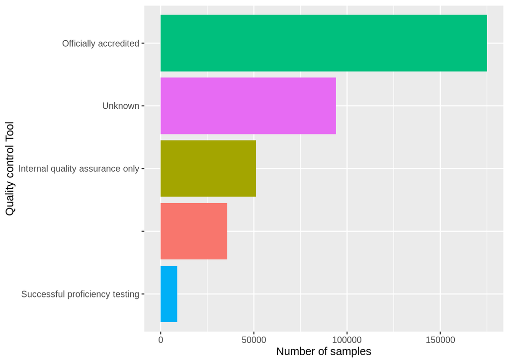

```r
ggplot(GEMS)+geom_bar(aes(reorder(AnalyticalQAName,AnalyticalQAName,function(x)+length(x))
                        ,fill=AnalyticalQAName), show.legend= FALSE, stat = "count")+
  coord_flip()+
  xlab("AnalyticalQAName")+xlab("Quality control Tool")+ylab("Number of samples")
```

Figura 2. Tipo de controle de qualidade do ensaio usado em relação ao número de amostras no banco de dados.

Vemos que o equivalente a aproximadamente 48% (175.133) dos ensaios foram realizados em laboratórios acreditados e 16% (51139) tinha algum controle interno de qualidade ou ensaio de proficiência.

Investigamos agora, se a origem dos dados analíticos (uso ou não de uma laboratório acreditado) interfere com a média/espalhamento dentro dos dados de cada país. Primeiro, calculamos a média entre todas as amostras mas levando em consideração todos os resultados quantificados, primeiro um resumo dos dados totais:

média total:

```r
GEMS2 %>% group_by(CountryName) %>%  summarise(mean=mean(ResultValue,na.rm=TRUE), n=n())
```

| CountryName | mean | n |
| --- | --- | --- |
| Canada | 0.018434030 | 48909 |
| China | 0.159482973 | 26633 |
| United States of America | 0.003971696 | 18378 |
| Brazil | 0.048771101 | 16166 |
| Thailand | 0.097709186 | 10624 |
| WHO European Region | 0.207825981 | 198592 |

Plotando:

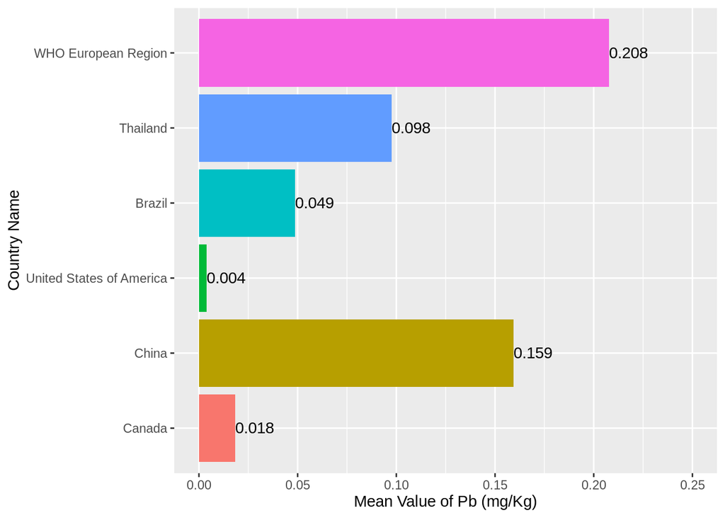

```r
GEMS2 %>%
  group_by(CountryName) %>%
  summarise(mean=mean(ResultValue,na.rm=TRUE), n=n())%>%
  arrange(desc(n),na.rm=TRUE)%>%
  ggplot(aes(mean,CountryName ,fill=CountryName))+
  geom_col(show.legend = FALSE)+
  geom_text(aes(label = format(round(mean, 3), nsmall = 2)), vjust = 0.5,hjust=0)+xlim(c(0,0.25))+ylab("Country Name")+xlab("Mean Value of Pb (mg/Kg)")
```

Figura 3. Valor médio de Chumbo (mg/Kg) em amostras conforme o pais de origem.

```r
GEMS2 %>% group_by(CountryName) %>%  summarise(mean=mean(ResultValue>=0.001,na.rm=TRUE), n=n())%>%arrange(desc(n),na.rm=TRUE)
```

| CountryName | mean | n |
| --- | --- | --- |
| WHO European Region | 0.4118924 | 198592 |
| Canada | 0.5294337 | 48909 |
| China | 0.6740885 | 26633 |
| United States of America | 0.2584834 | 18378 |
| Brazil | 0.2769097 | 16166 |
| Thailand | 0.3493351 | 10624 |

Na forma de gráfico de barras agora:

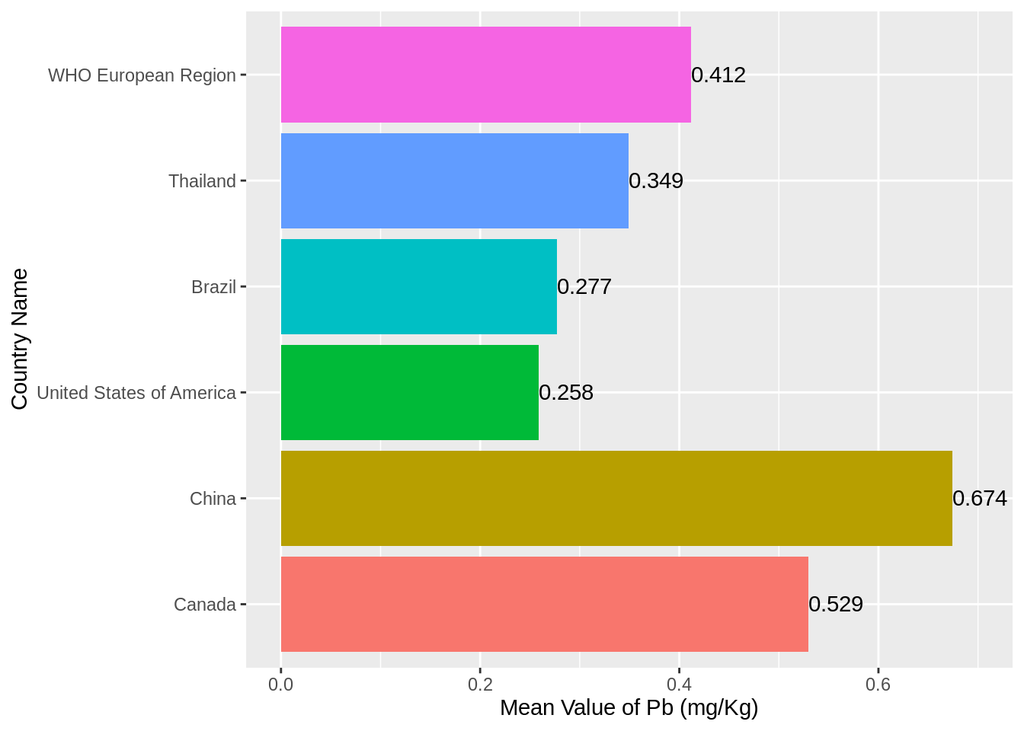

```r
GEMS2 %>%
  group_by(CountryName) %>%
  summarise(mean=mean(ResultValue>=0.001,na.rm=TRUE), n=n())%>%
  arrange(desc(n),na.rm=TRUE)%>%
  ggplot(aes(mean,CountryName ,fill=CountryName))+
  geom_col(show.legend = FALSE)+
  geom_text(aes(label = format(round(mean, 3), nsmall = 2)), vjust = 0.5,hjust=0)+xlim(c(0,0.70))+ylab("Country Name")+xlab("Mean Value of Pb (mg/Kg)")
```

Para verificar se a fonte da diferença pode ser o uso de laboratórios não acreditados, iremos excluir estes dados no dataframe “GEMS3”

```r
GEMS3=subset(GEMS2,GEMS2$AnalyticalQAName=="Officially accredited")
```

Repetindo agora o teste para ver se houve alteração nas médias:

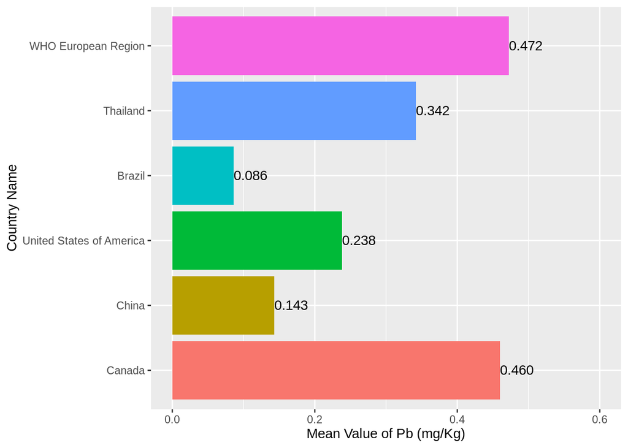

```r
GEMS3 %>% group_by(CountryName) %>%  summarise(mean=mean(ResultValue>=0.001,na.rm=TRUE), n=n())%>%arrange(desc(n),na.rm=TRUE)%>% ggplot(aes(mean,CountryName ,fill=CountryName))+geom_col(show.legend = FALSE)+geom_text(aes(label = format(round(mean, 3), nsmall = 2)), vjust = 0.5,hjust=0)+xlim(c(0,0.60))+ylab("Country Name")+xlab("Mean Value of Pb (mg/Kg)")
```

Quando avaliados dados somente de amostras quantificadas e de laboratórios acreditados, Europa e Canadá tem medias bem parecidas.

## 4.3 Distribuição conforme matriz (FoodCategory)

Analisaremos agora os teores de cada matriz (Variável “FoodCategory” no GEMS). Abaixo estão todos os resultados quantificados(considerando os 6 principais países contribuintes) em Chumbo por mg/kg (eixo x) para cada tipo de alimento(eixo y):

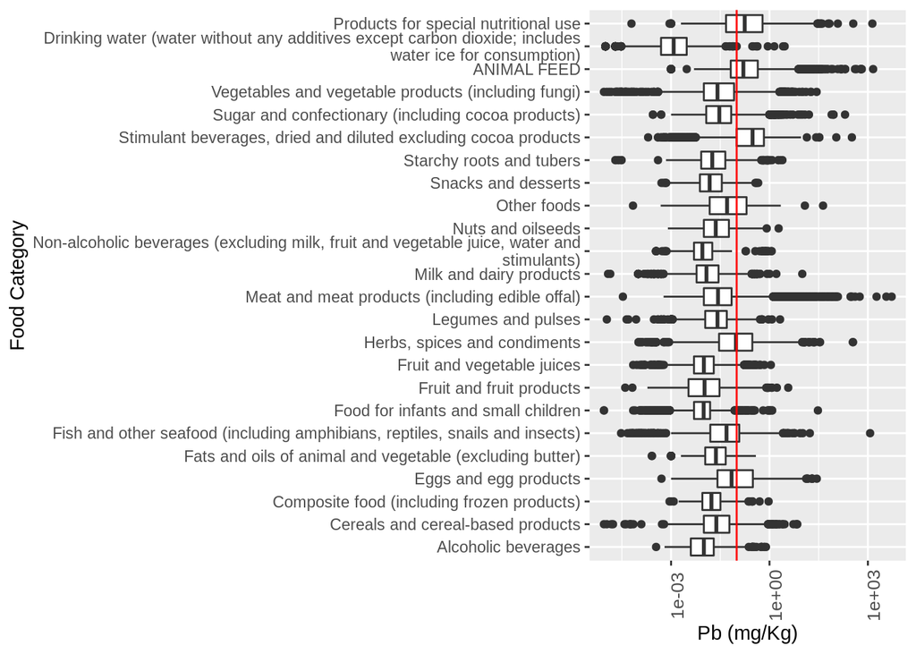

```r
ggplot(GEMS2, aes(x=FoodCategory,y=ResultValue))+
    geom_boxplot(show.legend = FALSE)+geom_hline(yintercept=0.1, linetype="solid", color = "red")+
    scale_y_log10()+
    scale_x_discrete(breaks=unique(GEMS$FoodCategory),labels = function(x) str_wrap(str_replace_all(x, "gjgj" , " "), width = 80))+
    coord_flip()+theme(axis.text.x = element_text(angle = 90,size =10))+xlab("Food Category")+ylab("Pb (mg/Kg)")
```

Figura 5: Boxplot dos teores de Chumbo em mg/Kg em alimentos de acordo com a matriz. As caixas representam 50% dos dados, as barras horizontais os outros 50%. Pontos alem das barras representam outliers.

A linha vermelha representa o limite de 0,1mg mg/Kg de Pb adotado como padrão em diversas legislações [2]. Apenas 4 matrizes(alimentos) tem sua mediana no limite ou acima dele: Ervas e Temperos, Bebidas estimulantes,ração animal e produtos para uso especial. OBS: Escala do eixo Y está em log10 para facilitar a visualização dos dados.

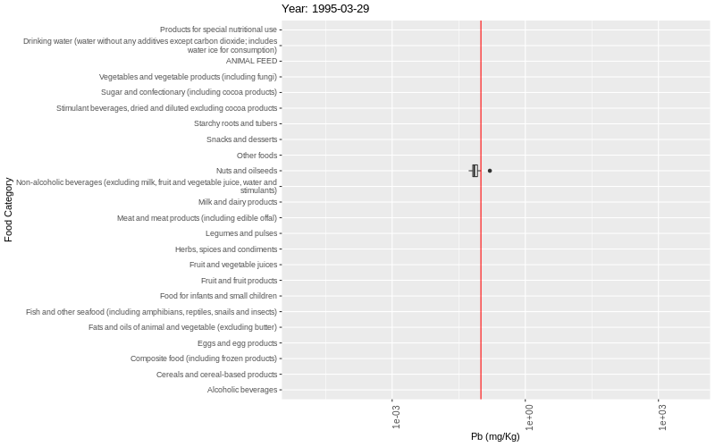

Nota-se durante a evolução dos anos uma alteração nas médias provavelmente causada por sazonalidade.

Vamos visualizar agora a distribuição na forma de Boxplot de cada alimento (dado categórico “FoodCategory”)separado nos seis principais paises contribuintes:

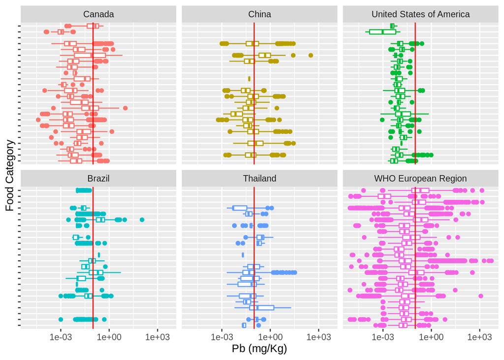

```r
ggplot(GEMS2, aes(ResultValue,FoodCategory,  color=CountryName))+
      geom_boxplot(show.legend = FALSE)+scale_x_log10()+theme(axis.text.y = element_blank())+geom_vline(xintercept=0.1, linetype="solid", color = "red")+facet_wrap(~CountryName)+ylab("Food Category")+xlab("Pb (mg/Kg)")
```

Figura 7: Boxplot dos teores de Chumbo em mg/Kg em alimentos de acordo com a matriz (eixo Y).

A linha vermelha representa o limite de 0.1mg/kg, rotineiramente adotado como limite para Chumbo em alimentos internacionalmente [4].

Nota-se uma quantidade muito maior de outliers na União Européia do que no segundo maior contribuinte (Canadá). Estes outliers se entendem ate concentrações bastante altas (até mesmo 100mg/Kg!) causando uma alavanca e “puxando” as medias totais para cima.

# 5. Um estudo mais profundo dos teores de Chumbo na região da União Européia

Para buscar por alguma possível alteração na qualidade dos ensaios conforme o tempo, vamos converter todas as datas para ano.

```r
GEMS2$SamplingPeriodEnd <- as.POSIXct(GEMS2$SamplingPeriodEnd, format = "%m/%d/%Y %H:%M:%S")
GEMS2$SamplingPeriodEnd <- format(GEMS2$SamplingPeriodEnd, format="%Y")
```

Visto que a região WHO/Europa apresenta grande quantidade de dados e muitos outliers/valores acima do permitido, ela foi escolhida para avaliação das matrizes e sua distribuição ao longo dos anos de forma mais detalhada.

Examinaremos agora as amostras quantificadas (acima de 0,001mg/kg) na “WHO European Region” na forma de um heatplot:

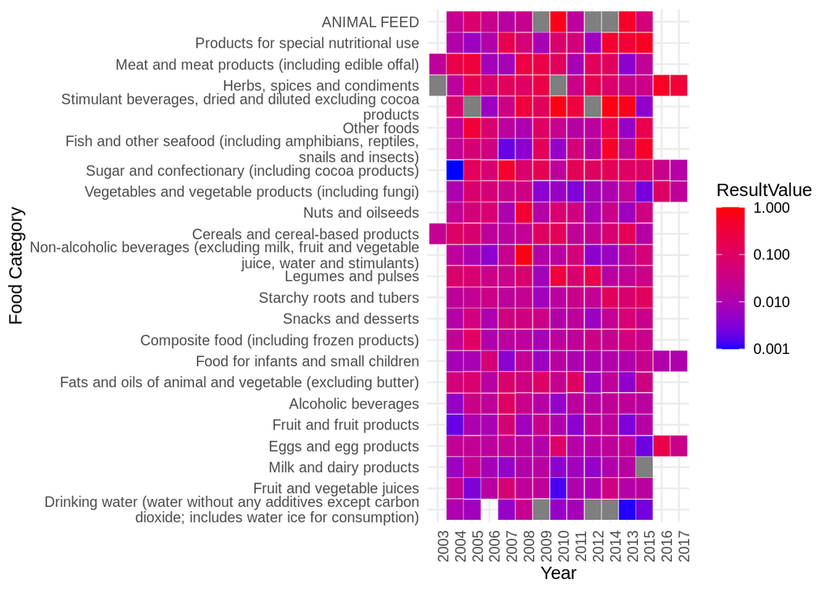

```r
 subset(GEMS2, GEMS2$CountryName=="WHO European Region" & GEMS2$ResultValue) %>%
  ggplot(aes(SamplingPeriodEndText,y=reorder(FoodCategory, ResultValue,function(x)+mean(x)),  fill = ResultValue))+
  geom_tile(color = "white") +
  scale_fill_gradient(limits=c(0.001, 1),low = "blue", high ="red", trans="log10")+
  theme_minimal() +
  theme(axis.text.x = element_text(angle = 90),)+ylab("FoodCategory")+
  scale_y_discrete(labels = function(x) str_wrap(str_replace_all(x, "gjgj" , " "), width = 60))+
  xlab("Year")+ylab("Food Category")
```

Figura 8. Heatplot do período de 15 anos de análises de teor de Chumbo em alimentos na OMS/Europa. Vermelho representa o teor de 1mg/Kg, azul 0,001mg/kg. Nota-se que ao longo dos anos amostras de Ervas e temperos, bebidas estimulantes e ração animal, continuamente apresentam resultados mais altos do que outras matrizes. conforme já visto no boxplot da figura 7.

A parte superior do Heatplot contem os alimentos com valores médios mais altos ao longo dos anos e os inferiores, com os menores.

```r
quantile(subset(GEMS2$ResultValue,GEMS2$CountryName=="WHO European Region"),probs=(0.95),na.rm=TRUE)
##   95%
## 0.201
mean(subset(GEMS2$ResultValue,GEMS2$CountryName=="WHO European Region"),na.rm=TRUE)
## [1] 0.207826
```

```r
quantile(subset(GEMS2$ResultValue,GEMS2$CountryName=="WHO European Region"),probs=(0.98),na.rm=TRUE)
##  98%
## 0.58
```

98% das amostras quantificadas estão abaixo de 0.58mg/Kg.

```r
quantile(subset(GEMS2$ResultValue,GEMS2$CountryName=="WHO European Region"),probs=(0.99),na.rm=TRUE)
##  99%
## 1.21
```

99% das amostras quantificadas estão abaixo de 1.21mg/Kg.

Observando estes limites no histograma de frequência:

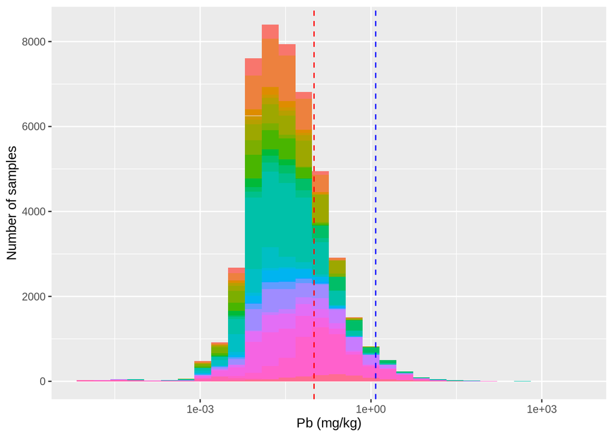

```r
subset(GEMS3, GEMS3$CountryName=="WHO European Region" & GEMS3$ResultValue) %>%
  ggplot(aes(ResultValue, fill=FoodCategory))+
  geom_histogram( show.legend= FALSE)+
  geom_vline(xintercept=0.1, linetype="dashed", color = "red")+
  geom_vline(xintercept=1.21, linetype="dashed", color = "blue")+
  scale_x_log10()+xlab("Pb (mg/kg)")+ylab("Number of samples")
```

```r
shapiro.test(sample(subset(GEMS3$ResultValue, GEMS3$CountryName=="WHO European Region"),5000))
##
##  Shapiro-Wilk normality test
##
## data:  sample(subset(GEMS3$ResultValue, GEMS3$CountryName == "WHO European Region"),     5000)
## W = 0.0066889, p-value < 2.2e-16
t.test(subset(GEMS3$ResultValue, GEMS3$CountryName=="WHO European Region"))
##
##  One Sample t-test
##
## data:  subset(GEMS3$ResultValue, GEMS3$CountryName == "WHO European Region")
## t = 4.2531, df = 97261, p-value = 2.11e-05
## alternative hypothesis: true mean is not equal to 0
## 95 percent confidence interval:
##  0.08983044 0.24338904
## sample estimates:
## mean of x
## 0.1666097
```

## 5.1 Relação dinâmica entre Qualidade do ensaio e origem da amostra

Sabemos agora que a grande maioria das amostras (60%) fica abaixo do limite de quantificação e por simplicidade é reportada como 0,000. Uma quantidade mínima e quantificada e fica abaixo do limite da legislação. O restante (40%) é quantificada e 99% das vezes fica abaixo de 1,22mg/Kg.

Buscaremos agora visualizar como essas informações se relacionam entre si usando o gráfico de Sankey. Este gráfico é similar ao de barras empilhadas porém, com linhas que mostram as relações entre as variáveis.

```r
Sankey <-read_csv("/mnt/DADOS/Data Science/GEMFoods/Sankey2")
Sankey$a = as.factor(Sankey$a)
Sankey$b = as.factor(Sankey$b)
Sankey$c = as.factor(Sankey$c)
```

Vamos relacionar a Origem das amostras (Domestica ou importada), a ferramenta de controle de qualidade e o teor de chumbo quantificado:

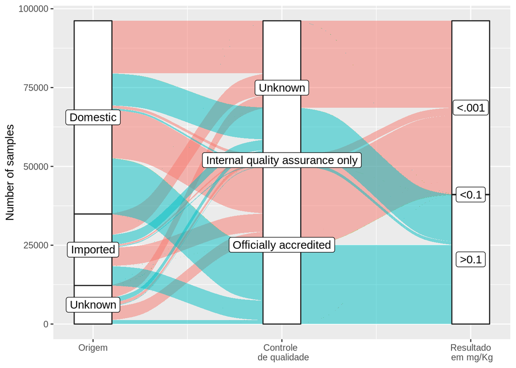

```r
library(alluvial)
library(ggalluvial)

ggplot(as.data.frame(Sankey), aes(y = d, axis1 = a, axis2 = b, axis3 = c)) +
  geom_alluvium(aes(fill = c, colors=a), width = 1/6) +
  geom_stratum(width = 1/5, fill = "white", color = "grey10") +
  scale_x_continuous(breaks = 1:3, labels = c("Origem", "Controle \n de qualidade", "Resultado\n em mg/Kg")) +
  geom_label(stat = "stratum", aes(label = after_stat(stratum))) +  theme(legend.position = "none")+ylab("Number of samples")
```

Figura 10: Gráfico de Sankey mostrando a relação entre a origem, a técnica de controle de qualidade usada e o resultado em mg/Kg. Pode-se notar que tanto por origem, Controle de qualidade ou resultado não há nenhuma tendência. Nota-se também que entre as amostras domésticas e importadas apresentam a mesma razão entre quantificadas acima de 0,1 mg/Kg e abaixo do limite de quantificação.

## 5.2 Em busca das matrizes com teores mais altos

Vamos investigar somente as amostras com teores mais altos, Ervas e temperos, ração animal, bebidas estimulantes e Produtos para uso nutricional especial. Primeiro, como elas se relacionam com o tempo e a quantidade de amostras testadas e quantificadas:

```r
GEMS4=subset(GEMS2, GEMS2$CountryName=="WHO European Region" & GEMS2$FoodCategory=="ANIMAL FEED" | GEMS2$FoodCategory=="Stimulant beverages, dried and diluted excluding cocoa products" | GEMS2$FoodCategory=="Herbs, spices and condiments"  | GEMS2$FoodCategory=="Products for special nutritional use")
```

```r
GEMS5=subset(GEMS2, GEMS2$CountryName=="WHO European Region")
```

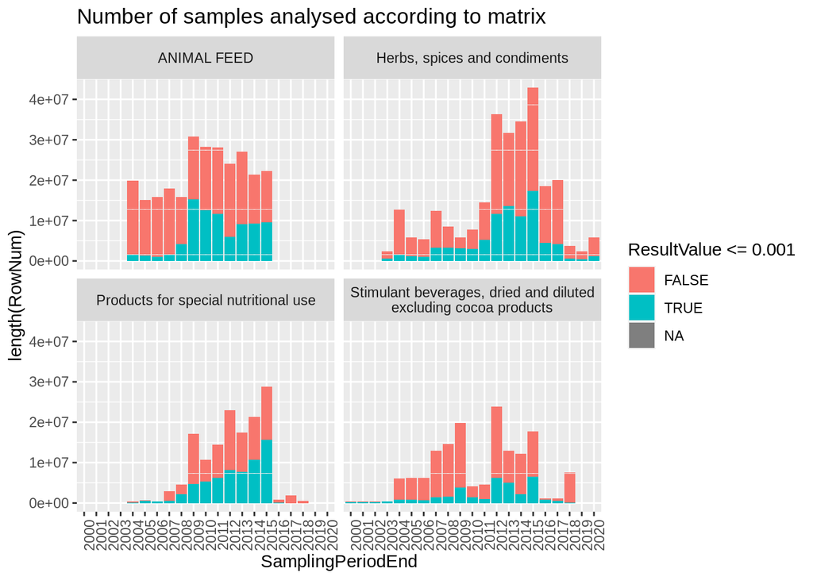

```r
ggplot(GEMS4,aes(x=SamplingPeriodEnd,y=length(RowNum), fill=ResultValue<=0.001))+
  geom_bar(position="stack", stat="identity")+ theme(axis.text.x = element_text(angle = 90),)+
  facet_wrap(~str_wrap(FoodCategory,width = 40))+ggtitle("Number of samples analysed according to matrix")
```

Figura 11. Gráficos de barras agrupando as 4 principais classes com maiores valores médios de Chumbo no período de 25 anos. A número de amostras quantificadas é demonstrada pela diferença de cores (Vermelho quantificado, Azul abaixo do LOQ).

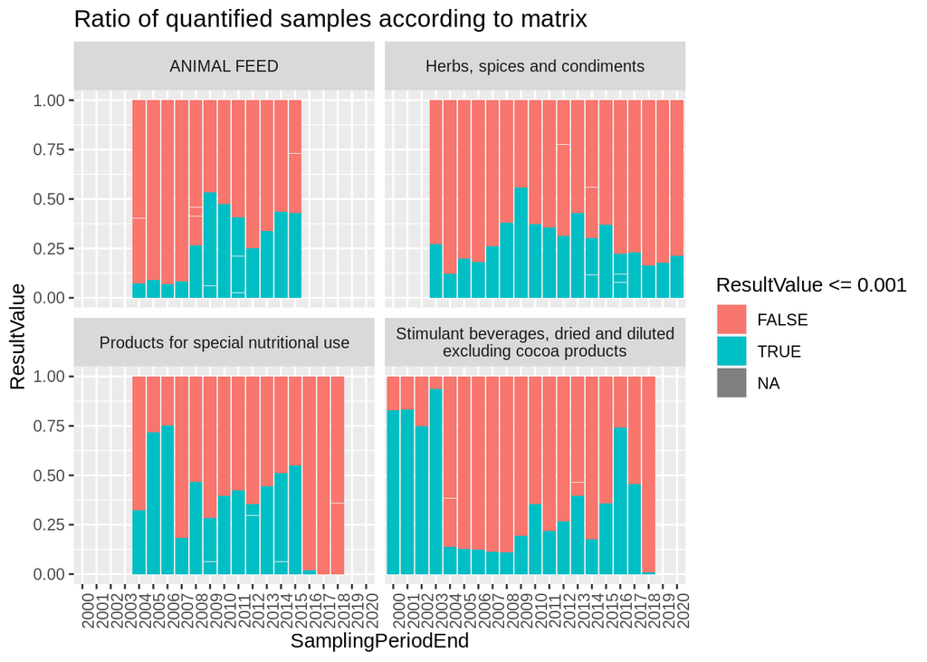

```r
ggplot(GEMS4,aes(x=SamplingPeriodEnd,y=(RowNum), fill=ResultValue<=0.001))+
  geom_bar(position="fill", stat="identity")+ theme(axis.text.x = element_text(angle = 90),)+
  facet_wrap(~str_wrap(FoodCategory,width = 40))+ylab("ResultValue")+ggtitle("Ratio of quantified samples according to matrix")
```

Figura 12. Gráficos de barras agrupando as 4 principais classes com maiores valores médios de Chumbo no período de 25 anos. Os valores foram normatizados sendo que cada coluna corresponde a 100% dos valores e a razão entre amostras quantificadas e não quantificadas é demonstrada pela diferença de cores (Vermelho quantificado, Azul abaixo do LOQ).

Nota-se que quando as amostras de Ervas e temperos apresentam amostras quantificadas rotineiramente por um período superior a 10 anos e mesmo com variação no número de amostras a quantidade quantificada é muito próxima. Alguns anos em que ocorre a fuga do padrão, e possível ver que o número total de amostras é menor (por exemplo amostras de bebidas estimulantes no início dos anos 2000)

Sabemos até agora que esses quatro grupos de alimentos são frequentemente quantificados. Porém,não está claro se algumas amostras possuem teores muito altos e “arrastam” a média para concentrações mais altas.

Para isso vamos avaliar um boxplot com 99% dos dados (para evitar outliers) e ver onde os quartis se localizam:

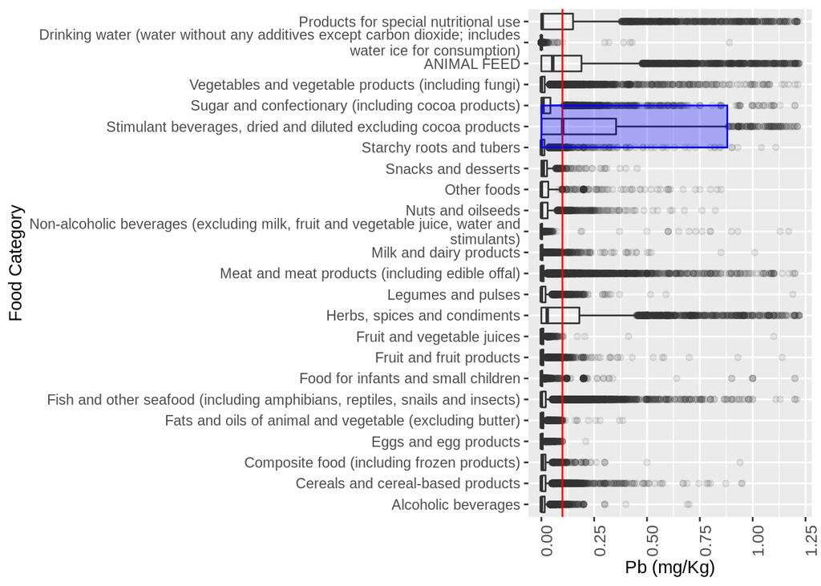

```r
ggplot(GEMS5, aes(x=FoodCategory,y=ResultValue))+
    geom_boxplot(show.legend = FALSE,alpha=1/10)+geom_hline(yintercept=0.1, linetype="solid", color = "red")+
        scale_x_discrete(breaks=unique(GEMS$FoodCategory),labels = function(x) str_wrap(str_replace_all(x, "gjgj" , " "), width = 80))+ylim(c(0,1.22))+
    coord_flip()+theme(axis.text.x = element_text(angle = 90,size =10))+xlab("Food Category")+ylab("Pb (mg/Kg)")+annotate("rect",ymin = 0,ymax=0.88, xmin = "Starchy roots and tubers",xmax="Sugar and confectionary (including cocoa products)", alpha=0.3, color="blue", fill="blue")
```

Figura 13. Boxplot com eixo linear contemplando 99% das amostras na faixa de 0.001 a 1.22mg/kg de Pb.

Podemos ver que o pior caso é o das bebidas estimulantes que englobam cafés e chás. A mediana se localiza bem no limite de 0.1mg/kg e o terceiro quartil(50% a 75%) se alonga até mais de 0.25mg/kg.

Através da distribuição cumulativa, vemos que o problema não são outliers mas uma grande quantidade de amostras em diversas concentrações que é quantificada nessa classe:

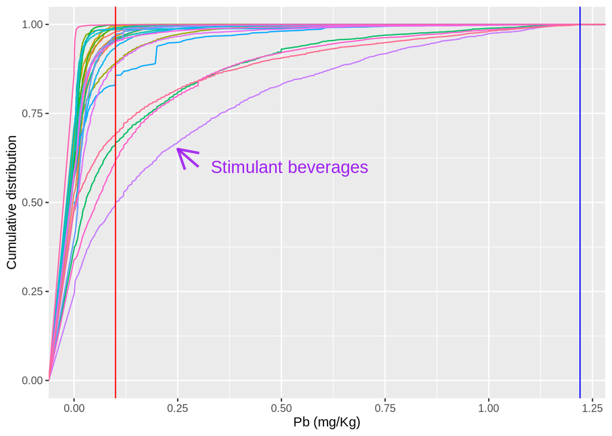

```r
ggplot(GEMS5, aes(x=ResultValue, color=FoodCategory, label=FoodCategory),show.legend = FALSE)+
    stat_ecdf(geom = "line", aes(ResultValue),show.legend = FALSE) +xlab("Pb (mg/Kg)")+geom_vline(xintercept=0.1, linetype="solid", color = "red")+geom_vline(xintercept=1.22, linetype="solid", color = "blue")+xlim(c(0,1.22))+annotate("text", x = 0.52, y = 0.6,
label = c("Stimulant beverages") , color="purple",size=5 )+annotate("segment", x = 0.30, xend = 0.25, y = 0.6, yend = 0.65, colour = "purple", size=1, alpha=0.9, arrow=arrow())+ylab("Cumulative distribution")
```

Figura 14. Gráfico com distribuição cumulativa do teor de Chumbo nas amostras de alimentos na União Europeia. Linha vermelha representa a concentração de 0.1mg/kg de Pb e linha azul 1.22mg/kg que é o teor que engloba 99% das amostras.

Investigamos se dentro da classe de bebidas estimulantes, qual seria a pior matriz.

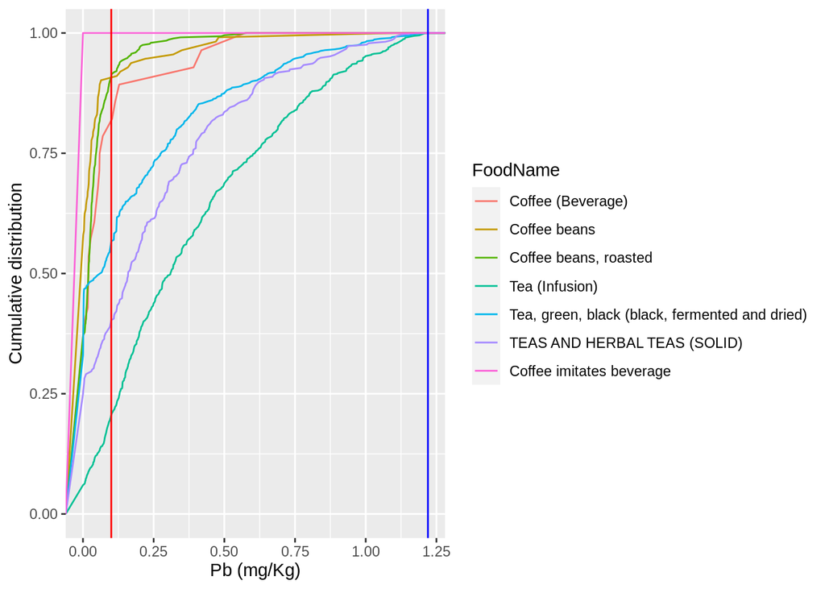

```r
ggplot(subset(GEMS5,GEMS5$FoodCategory=="Stimulant beverages, dried and diluted excluding cocoa products") , aes(x=ResultValue, color=FoodName, label=FoodName))+
    stat_ecdf(geom = "line", aes(ResultValue)) +xlab("Pb (mg/Kg)")+geom_vline(xintercept=0.1, linetype="solid", color = "red")+geom_vline(xintercept=1.22, linetype="solid", color = "blue")+xlim(c(0,1.22))+ylab("Cumulative distribution")
```

Figura 15. Gráfico com distribuição cumulativa do teor de Chumbo nas amostras de alimentos na União Europeia dentro da categoria “Bebidas estimulantes”. Linha vermelha representa a concentração de 0.1mg/kg de Pb e linha azul 1.22mg/kg que é o teor que engloba 99% das amostras.

O pior caso são as infusões de chá, onde mais de 50% das amostras apresentaram teores acima de 0.25mg/kg de Chumbo ou 2,5x mais que o limite.

# 6. Conclusão

A maior parte dos alimentos com altos valores de Chumbo possuem ingestão bastante limitada: “ANIMAL FEED” (obviamente), “Stimulant beverages” (uso ocasional),“Herbs, spices and condiments” (apenas como ingredientes e em pequenas quantidades). Apenas “Products for special nutritional use” (Como alimentação parenteral) são críticos pois podem resultar em uma ingestão mais alta por períodos mais longos

Não há indicativos que que amostras importadas (União Europeia) sejam quantificadas mais frequentemente do que as importadas, indicando contaminação na fonte.

Restam dúvidas técnicas como se as amostras de chás(Stimulant beverages) foram digeridas a partir da massa seca ? As amostras identificadas como “infusion” foram lidas “pronta para consumo” ou seja leitura direta? Qual a possibilidade real de erros de transcrição nos resultados como ug/kg reportado como mg/kg?

Referencias:

https://www.fda.gov/food/metals-and-your-food/lead-food-foodwares-and-dietary-supplements